# Dotchart

Sanghoo Yoon

## dotchart() 함수

- 참고 : https://www.statmethods.net/graphs/dot.html

Dotchart는 barplot과 비슷하나 최소값과 최대값을 점선으로 표현하여 현재 값들의 위치를 확인하기 편하다.

이 때문에 순서를 표현하는데 barplot보다 주로 사용된다.

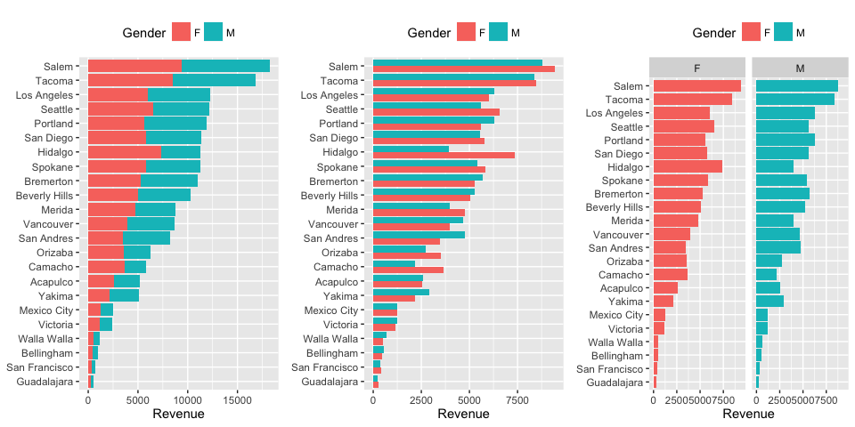

위의 그림은 지역에 따른 남여의 수입차이를 barplot으로 시각화 한 그림이다.

이제 dotchart로 표현해보자.

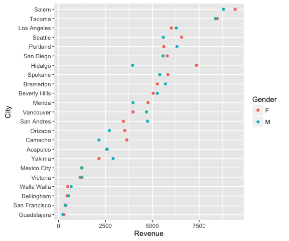

그림을 조금 더 가공하여 통계적 가설검정 결과도 추가하여 그린다면…

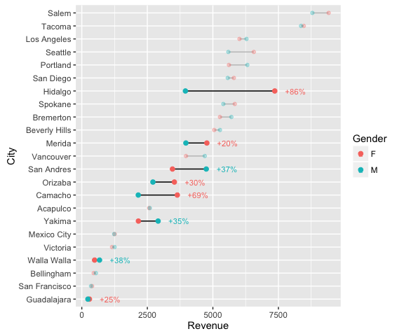

위의 그림은 ggplot2의 ggplot()함수를 통해 그린 그림이므로 이에 대한 자세한 내용은 내일 다루겠습니다.

오늘은 기본함수인 dotchart 사용법을 익힌다.

dotchart는 barplot과 비슷하게 vector 형식의 숫자가 있으면 된다.

- labels를 통해 dotchart의 이름을 붙힌다.

### Simple Dotplot

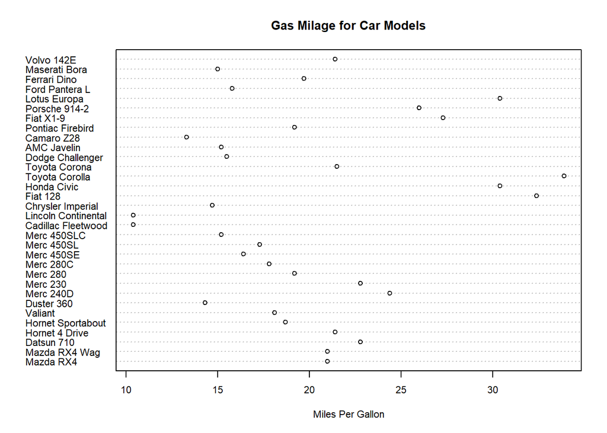

```r
dotchart(mtcars$mpg,
         labels=row.names(mtcars),cex=.7,
         main="Gas Milage for Car Models",
         xlab="Miles Per Gallon")
```

이제 그룹별로 색을 줘서 dotchart를 그려보자.

그룹의 색을 빨강, 파랑, 녹색을 주기 위해 color 변수를 추가로 생성하였다.

- group을 통해 factor로 변환된 자료를 그룹별로 시각화하였다.
- order()함수는 값의 크기에 따른 순서를 계산해주는 함수로 [] 안에 사용하면 자료가 정렬된다.

### Dotplot: Grouped Sorted and Colored

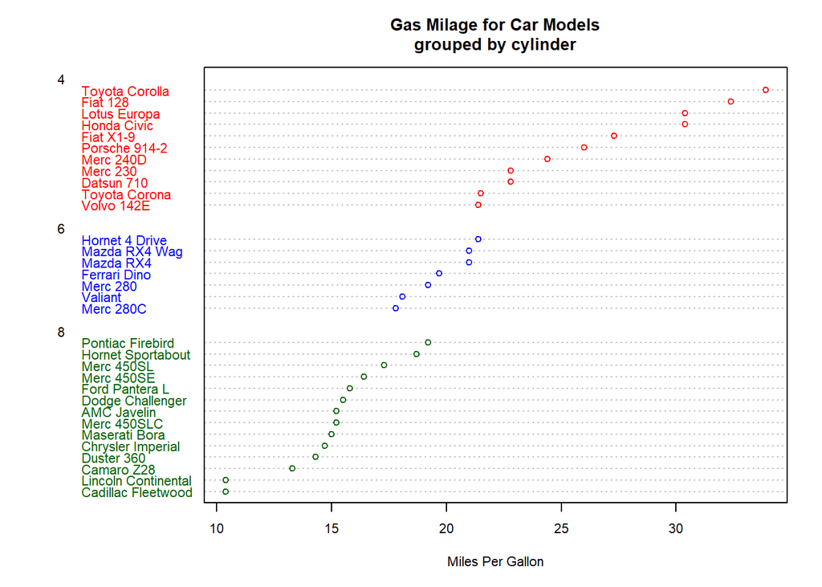

```r
x <- mtcars[order(mtcars$mpg),] # sort by mpg
x$cyl <- factor(x$cyl) # it must be a factor

x$color[x$cyl==4] <- "red"
x$color[x$cyl==6] <- "blue"
x$color[x$cyl==8] <- "darkgreen"

dotchart(x$mpg,labels=row.names(x),cex=.7,
         groups= x$cyl,
         main="Gas Milage for Car Models\ngrouped by cylinder",
         xlab="Miles Per Gallon", gcolor="black", color=x$color)
```

- 이제 기본적인 dotchart 사용법을 배웠다.
- 추가적인 옵션을 통해 풍성한 그림을 R로 그리는 방법을 배워보자.

dotchart도 barplot과 유사하게 벡터, 행렬에 따라 표현이 다르다.

또한 factor와 group을 통해 그룹핑하여 시각화가 가능하다.

```r
month <- matrix(1:12, ncol = 3)
rownames(month) <- paste("Row", 1:4)
colnames(month) <- paste("Col", 1:3)
month
```

```
##       Col 1 Col 2 Col 3
## Row 1     1     5     9
## Row 2     2     6    10
## Row 3     3     7    11
## Row 4     4     8    12
```

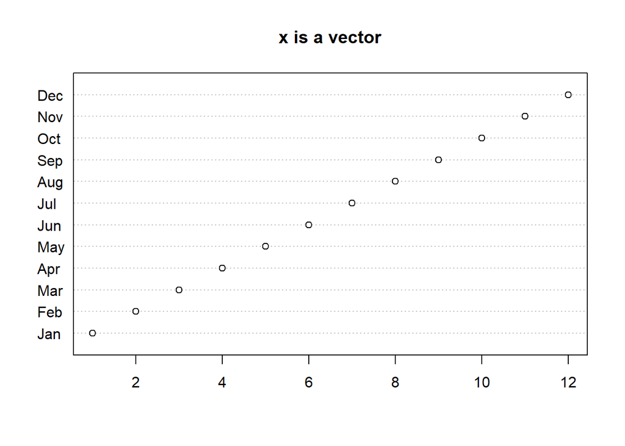

```r
# (1) 벡터
dotchart(as.vector(month), label = month.abb)
title(main = "x is a vector")
```

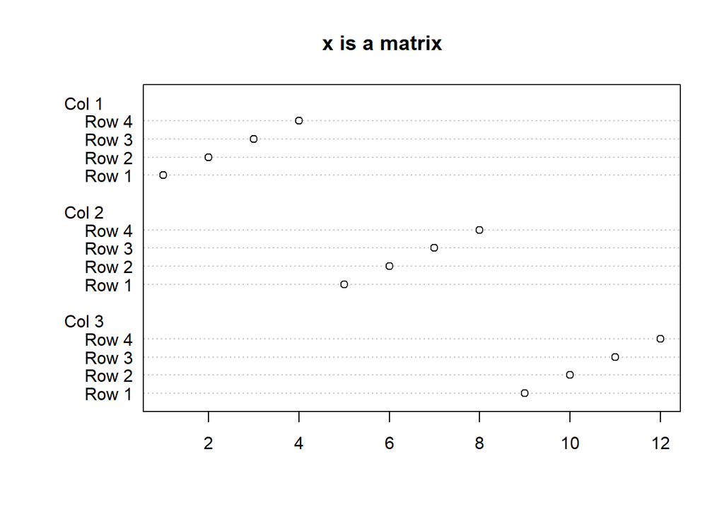

```r
# (2) 행렬
dotchart(month)
title(main = "x is a matrix")
```

```r
# (3) group
quarter.name <- c("1QT", "2QT", "3QT", "4QT")
quarter <- factor(row(month), label = quarter.name)
quarter
```

```
##  [1] 1QT 2QT 3QT 4QT 1QT 2QT 3QT 4QT 1QT 2QT 3QT 4QT
## Levels: 1QT 2QT 3QT 4QT
```

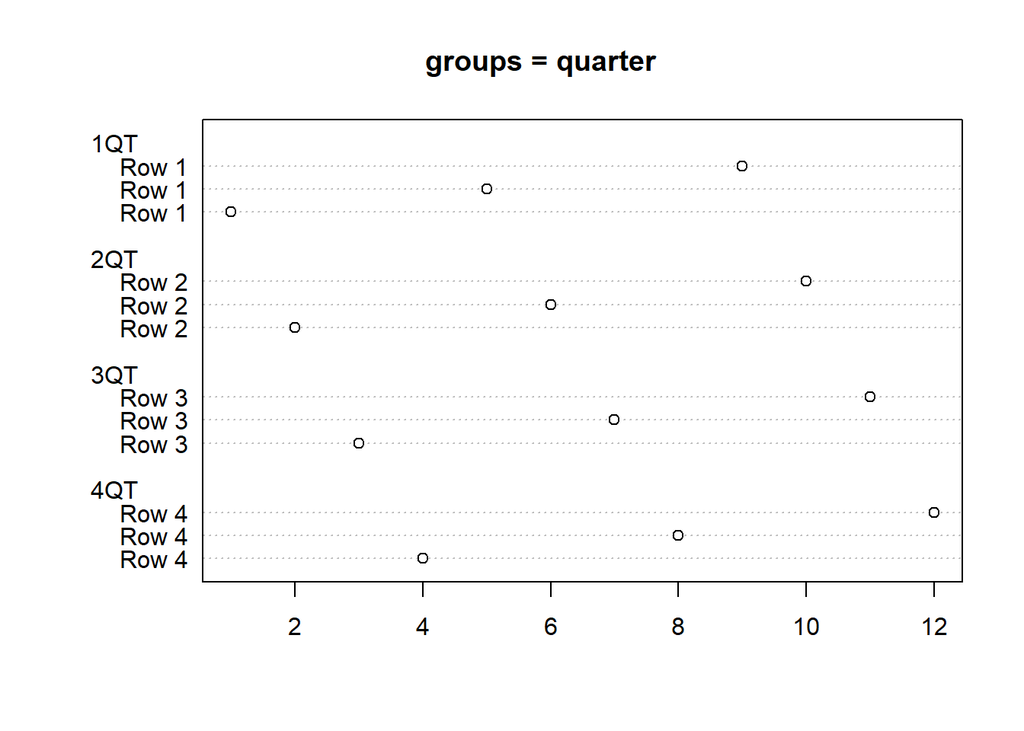

```r
dotchart(month, groups = quarter) # factor와 label을 통해 표현
title(main = "groups = quarter")
```

```r
# (4) groups, labels
name <- c("1st", "2nd", "3rd")
month
```

```
##       Col 1 Col 2 Col 3
## Row 1     1     5     9
## Row 2     2     6    10
## Row 3     3     7    11
## Row 4     4     8    12
```

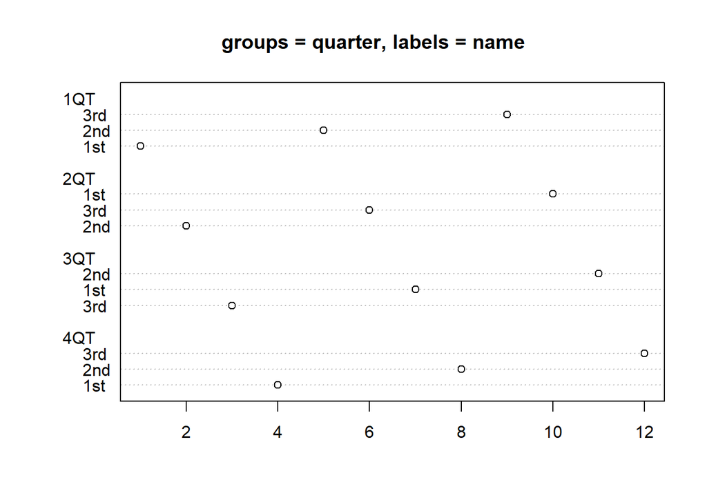

```r
dotchart(month, groups = quarter, labels = name)
title(main = "groups = quarter, labels = name")
```

- tapply 함수통해 month의 quarter별 평균을 계산하여 그림에 추가할 수 있다.
- 이 경우 gdata를 통해 그룹 요약값을 반영하자.

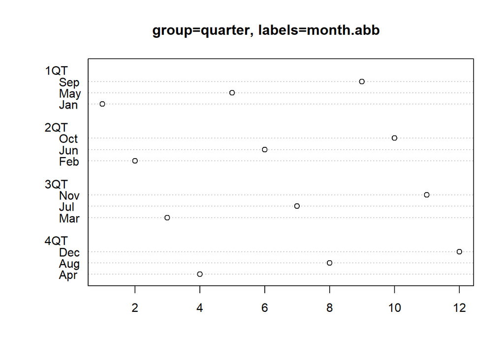

```r
dotchart(month, group = quarter, labels = month.abb)
title(main = "group=quarter, labels=month.abb")
```

```r
gmean <- tapply(month, quarter, mean)
gmean
```

```
## 1QT 2QT 3QT 4QT
##   5   6   7   8
```

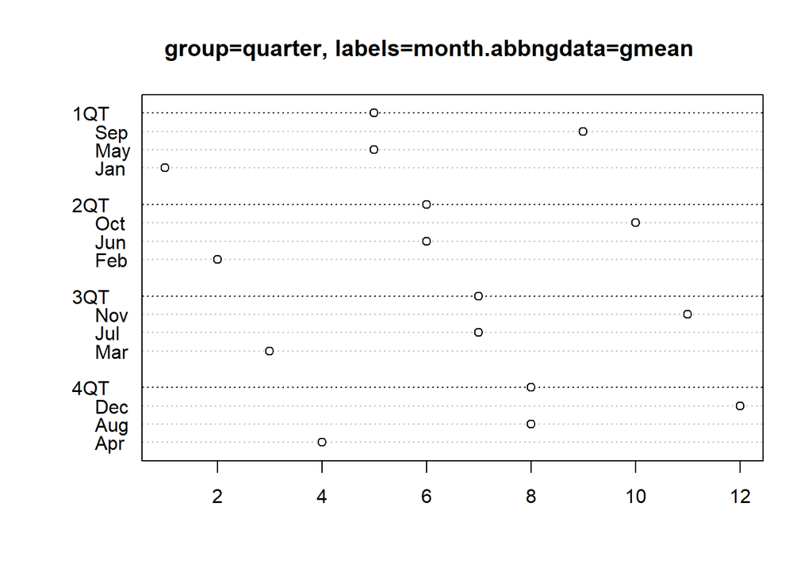

```r
dotchart(month, group = quarter, labels = month.abb, gdata = gmean)
title(main = "group=quarter, labels=month.abbngdata=gmean")
```

pch는 모양을 선택하는 옵션이다. 자세한 내용이 궁금하면 help에서 pch를 검색해보세요.

따라서 pch와 gpch를 이용하여 그림안 도형을 바꿔보자.

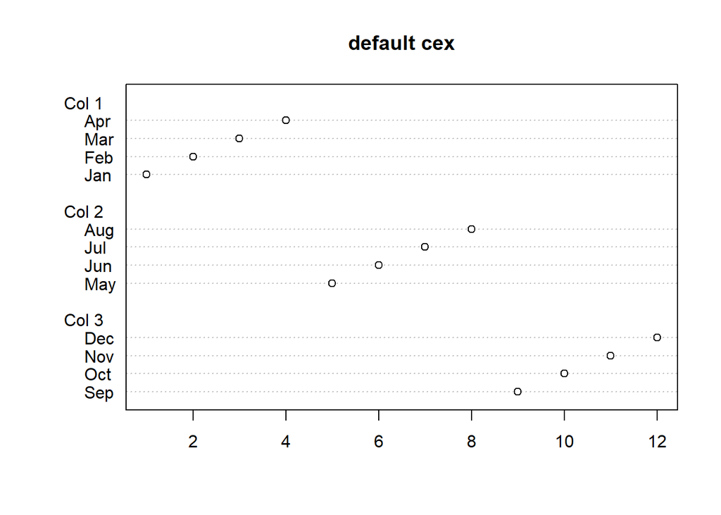

```r
dotchart(month, labels = month.abb, main = "default cex")
```

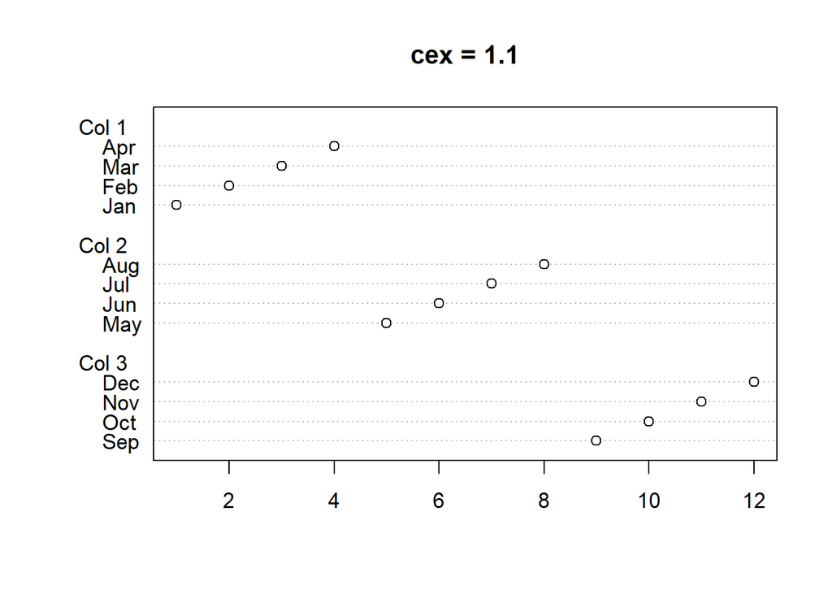

```r
dotchart(month, labels = month.abb, cex = 1.1, main = "cex = 1.1")
```

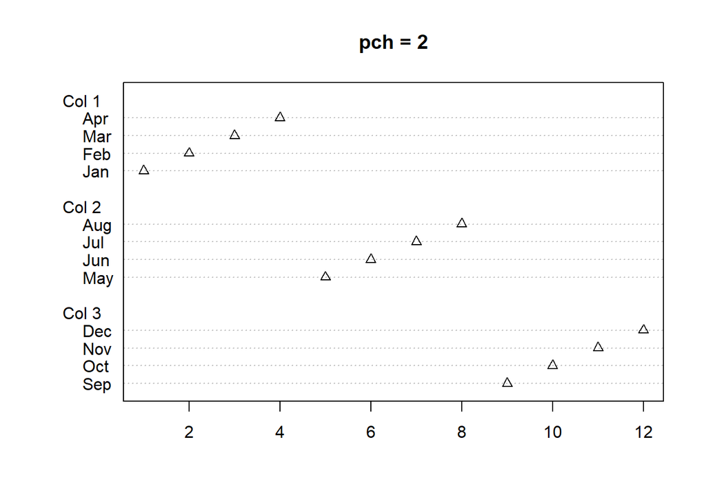

```r
dotchart(month, labels = month.abb, pch = 2, main = "pch = 2")
```

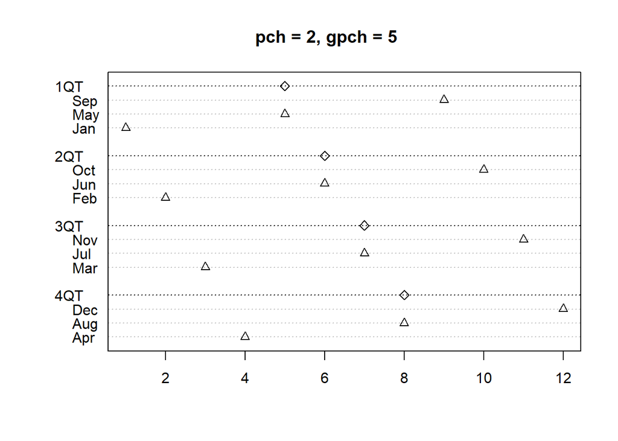

```r
dotchart(month, labels = month.abb, groups = quarter, pch = 2, gpch = 5, gdata = gmean)
title(main = "pch = 2, gpch = 5")
```

물론 color와 bg로 원하는 색을 바꿀 수 있다. gcolor와 lcolor도 있다.

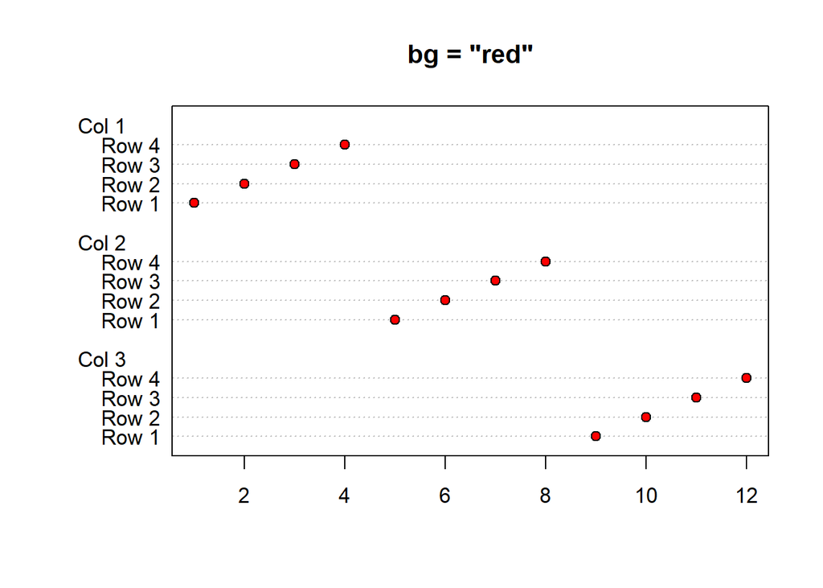

```r
dotchart(month, cex = 1.1, bg = "red", main = "bg = \"red\"")
```

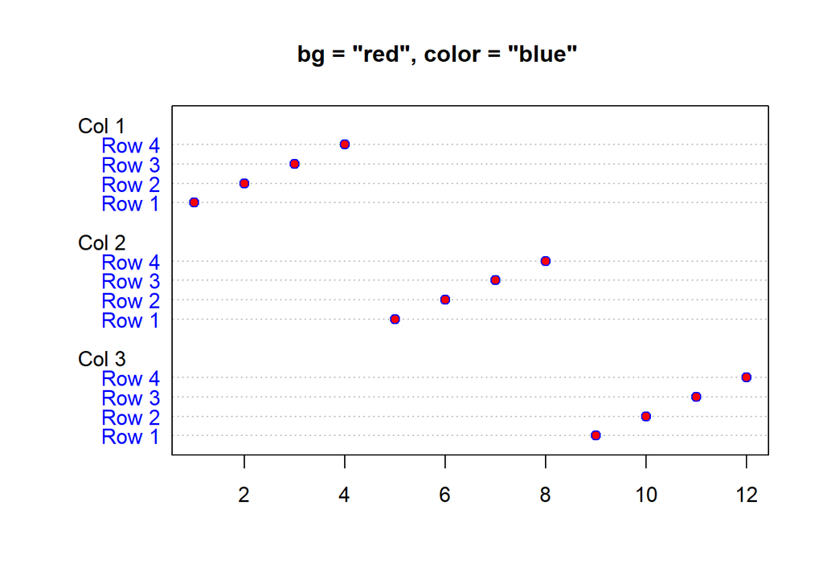

```r
dotchart(month, cex = 1.1, bg = "red", color = "blue")
title(main = "bg = \"red\", color = \"blue\"")
```

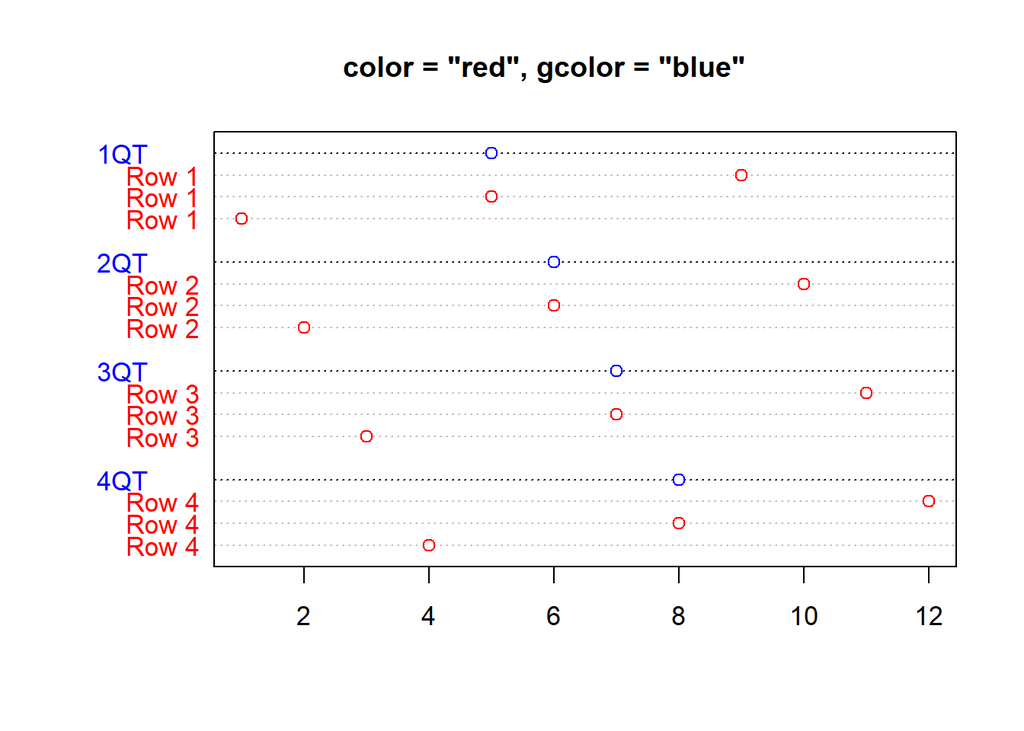

```r
dotchart(month, cex = 1.1, color = "red", gcolor = "blue", groups = quarter,
           gdata = gmean)

title(main = "color = \"red\", gcolor = \"blue\"")
```

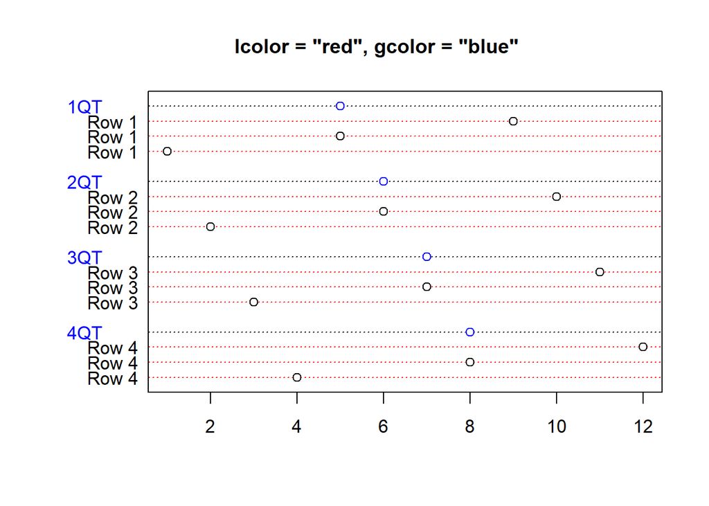

```r
dotchart(month, cex = 1.1, lcolor = "red", gcolor = "blue", groups = quarter,
           gdata = gmean)
title(main = "lcolor = \"red\", gcolor = \"blue\"")
```

기본적으로 dotchart는 수집된 자료의 최대값과 최소값으로 범위가 설정되므로

xlim을 통해 축을 크기를 변경할 있다.

또한 t()함수를 통해 자료를 전치하여 dotchart를 그릴 수 있다.

전치하면 행과 열이 바뀌므로 그룹변수가 자동으로 바뀜을 주의하자.

```r
VADeaths
```

```
##       Rural Male Rural Female Urban Male Urban Female
## 50-54       11.7          8.7       15.4          8.4
## 55-59       18.1         11.7       24.3         13.6
## 60-64       26.9         20.3       37.0         19.3
## 65-69       41.0         30.9       54.6         35.1
## 70-74       66.0         54.3       71.1         50.0
```

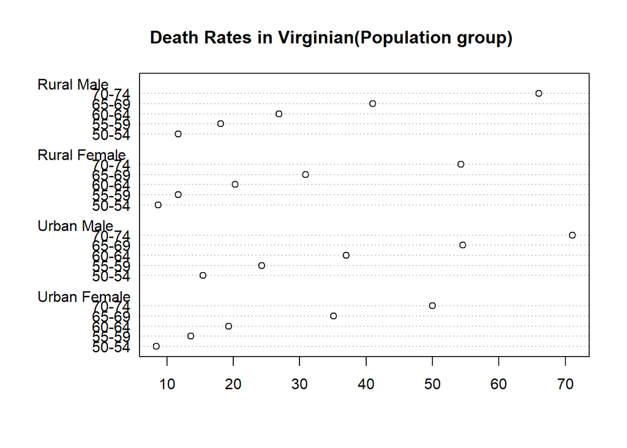

```r
dotchart(VADeaths)
title(main = "Death Rates in Virginian(Population group)")
```

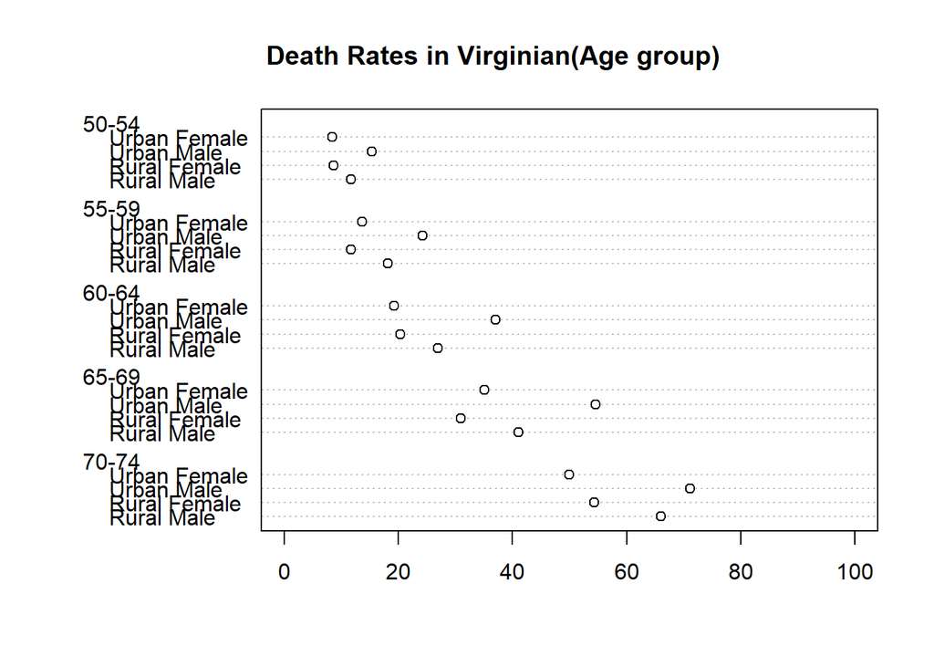

```r
dotchart(t(VADeaths), xlim = c(0, 100))
title(main = "Death Rates in Virginian(Age group)")
```